### Abdullah Imran

[figure not shown]

# **Data Alchemy: Iris Flower Classification 🔍✨**

# The Iris Flower Data Set

The **Iris flower data set** or **Fisher's Iris data set** is a multivariate data set introduced by the British statistician, eugenicist, and biologist **Ronald Fisher** in his 1936 paper *The use of multiple measurements in taxonomic problems* as an example of linear discriminant analysis【[1](https://en.wikipedia.org/wiki/Iris_flower_data_set#:~:text=The%20Iris%20flower%20data%20set,example%20of%20linear%20discriminant%20analysis.)】. It is sometimes called **Anderson's Iris data set** because **Edgar Anderson** collected the data to quantify the morphologic variation of Iris flowers of three related species【[2](https://en.wikipedia.org/wiki/Iris_flower_data_set#:~:text=The%20Iris%20flower%20data%20set,example%20of%20linear%20discriminant%20analysis.)】.

Two of the three species were collected in the Gaspé Peninsula "all from the same pasture, and picked on the same day and measured at the same time by the same person with the same apparatus"【[3](https://en.wikipedia.org/wiki/Iris_flower_data_set#:~:text=The%20Iris%20flower%20data%20set,example%20of%20linear%20discriminant%20analysis.)】. Fisher's paper was published in the journal, the **Annals of Eugenics**, creating controversy about the continued use of the Iris dataset for teaching statistical techniques today.

The data set consists of `150` records and `50` samples under 5 attributes from each of three species(Class) of Iris (`Iris setosa`, `Iris virginica` and `Iris versicolor`). Four features were measured from each sample: the `length` and the `width` of the `sepals` and `petals`, in centimeters(Petal Length, Petal Width, Sepal Length, Sepal width). Based on the combination of these four features, Fisher developed a linear discriminant model to distinguish the species from each other.You can download it [here](https://www.kaggle.com/datasets/arshid/iris-flower-dataset).

[figure not shown]

# Importing Libraries 📚

```python
# Loading, Preprocessing, Analysis Libraries
import numpy as np
import pandas as pd

# Visulaiztion Libraries
import seaborn as sns
import matplotlib.pyplot as plt
import plotly.express as px
import plotly.graph_objects as go
from plotly.subplots import make_subplots
%matplotlib inline


# Model Training And Testing libraries
from sklearn.model_selection import train_test_split

# Model Algorithms Libraries
from sklearn.neural_network import MLPClassifier
from sklearn.ensemble import RandomForestClassifier, GradientBoostingClassifier, HistGradientBoostingClassifier
from sklearn.tree import DecisionTreeClassifier
from sklearn.neighbors import KNeighborsClassifier
from sklearn.neural_network import MLPClassifier
from sklearn.naive_bayes import GaussianNB
from sklearn.linear_model import LogisticRegression
from sklearn.svm import SVC

# Pre-Processing Libraries
from sklearn.preprocessing import MinMaxScaler,StandardScaler, LabelEncoder

# Metrics & Hyper Parameter Libraries
from sklearn.metrics import roc_auc_score, precision_recall_curve, auc, confusion_matrix, recall_score, accuracy_score, precision_score, f1_score, classification_report, f1_score, roc_curve
from sklearn.model_selection import cross_val_score, GridSearchCV, RepeatedStratifiedKFold, KFold, StratifiedKFold

# Profiling Libraries
from ydata_profiling import ProfileReport
import os

# Library For Model Comparison
from sklearn.model_selection import KFold
```

# 1. | DataSet Exploration🔍

### 1.1 | Importing Dataset

```python
iris = pd.read_csv(r"C:\Users\acer\Downloads\Iris.csv")
```

### 1.2 | Profile Report

```python
flower_pf = ProfileReport(iris, title = 'Flower(Iris) DataSet Report', explorative = True)
flower_pf
```

[interactive chart not shown]

### 1.3 | Head & Tail

```python
iris.head()
```

|  | Id | SepalLengthCm | SepalWidthCm | PetalLengthCm | PetalWidthCm | Species |
| --- | --- | --- | --- | --- | --- | --- |
| 0 | 1 | 5.1 | 3.5 | 1.4 | 0.2 | Iris-setosa |
| 1 | 2 | 4.9 | 3.0 | 1.4 | 0.2 | Iris-setosa |
| 2 | 3 | 4.7 | 3.2 | 1.3 | 0.2 | Iris-setosa |
| 3 | 4 | 4.6 | 3.1 | 1.5 | 0.2 | Iris-setosa |
| 4 | 5 | 5.0 | 3.6 | 1.4 | 0.2 | Iris-setosa |

```python
iris.tail()
```

|  | Id | SepalLengthCm | SepalWidthCm | PetalLengthCm | PetalWidthCm | Species |
| --- | --- | --- | --- | --- | --- | --- |
| 145 | 146 | 6.7 | 3.0 | 5.2 | 2.3 | Iris-virginica |
| 146 | 147 | 6.3 | 2.5 | 5.0 | 1.9 | Iris-virginica |
| 147 | 148 | 6.5 | 3.0 | 5.2 | 2.0 | Iris-virginica |
| 148 | 149 | 6.2 | 3.4 | 5.4 | 2.3 | Iris-virginica |
| 149 | 150 | 5.9 | 3.0 | 5.1 | 1.8 | Iris-virginica |

### 1.4 | Shape & Info

```python
iris.info()
```

```
<class 'pandas.core.frame.DataFrame'>
RangeIndex: 150 entries, 0 to 149
Data columns (total 6 columns):
 #   Column         Non-Null Count  Dtype
---  ------         --------------  -----
 0   Id             150 non-null    int64
 1   SepalLengthCm  150 non-null    float64
 2   SepalWidthCm   150 non-null    float64
 3   PetalLengthCm  150 non-null    float64
 4   PetalWidthCm   150 non-null    float64
 5   Species        150 non-null    object
dtypes: float64(4), int64(1), object(1)
memory usage: 7.2+ KB
```

```python
iris.shape
```

```
(150, 6)
```

```python
iris.columns
```

```
Index(['Id', 'SepalLengthCm', 'SepalWidthCm', 'PetalLengthCm', 'PetalWidthCm',
       'Species'],
      dtype='object')
```

### 1.5 | Identifying Missing Values

```python
iris.isnull().sum()
```

```
Id               0
SepalLengthCm    0
SepalWidthCm     0
PetalLengthCm    0
PetalWidthCm     0
Species          0
dtype: int64
```

### 1.6 | Duplicate Rows

```python
iris.duplicated().any()
```

```
False
```

```python
# Print only the duplicate rows (excluding the first occurrence)
dup = iris[iris.duplicated()]
print("Duplicate rows (excluding the first occurrence):")
dup
```

```
Duplicate rows (excluding the first occurrence):
```

|  | Id | SepalLengthCm | SepalWidthCm | PetalLengthCm | PetalWidthCm | Species |
| --- | --- | --- | --- | --- | --- | --- |

### 1.7 | Statistical Summary

```python
iris.describe()
```

|  | Id | SepalLengthCm | SepalWidthCm | PetalLengthCm | PetalWidthCm |
| --- | --- | --- | --- | --- | --- |
| count | 150.000000 | 150.000000 | 150.000000 | 150.000000 | 150.000000 |
| mean | 75.500000 | 5.843333 | 3.054000 | 3.758667 | 1.198667 |
| std | 43.445368 | 0.828066 | 0.433594 | 1.764420 | 0.763161 |
| min | 1.000000 | 4.300000 | 2.000000 | 1.000000 | 0.100000 |
| 25% | 38.250000 | 5.100000 | 2.800000 | 1.600000 | 0.300000 |
| 50% | 75.500000 | 5.800000 | 3.000000 | 4.350000 | 1.300000 |
| 75% | 112.750000 | 6.400000 | 3.300000 | 5.100000 | 1.800000 |
| max | 150.000000 | 7.900000 | 4.400000 | 6.900000 | 2.500000 |

```python
iris.describe(include = 'object')
```

|  | Species |
| --- | --- |
| count | 150 |
| unique | 3 |
| top | Iris-setosa |
| freq | 50 |

### 1.9 | Iris Features Count

#### Saving Counts In Excel FIle

```python
def percent_counts(df, feature):
    total = df[feature].value_counts(dropna=False)
    percent = round(df[feature].value_counts(dropna=False, normalize=True) * 100, 2)
    percent_count = pd.concat([total, percent], keys=['Total', 'Percentage'], axis=1)
    return percent_count

# Assuming 'iris' is your DataFrame
# Construct the full file path
file_path = r'D:\Projects\Python\CodeSoft Internship\Iris_Project\Iris_Counts.xlsx'

# Create a Pandas Excel writer using XlsxWriter as the engine.
writer = pd.ExcelWriter(file_path, engine='xlsxwriter')

for col in iris.columns:
    # Apply percent_counts function to each column and save to Excel
    counts = percent_counts(iris, col)
    counts.to_excel(writer, sheet_name=col)

# Close the Pandas Excel writer to finalize the writing process.
writer.close()
print("File Saved")
```

```
File Saved
```

```python
percent_counts(iris, 'Species')
```

|  | Total | Percentage |
| --- | --- | --- |
| Iris-setosa | 50 | 33.33 |
| Iris-versicolor | 50 | 33.33 |
| Iris-virginica | 50 | 33.33 |

### 1.10 | Continuous and Categorical Variables

```python
continuous_values = []
categorical_values = []

for column in iris.columns:
    if iris[column].dtype == 'int64' or iris[column].dtype == 'float64':
        continuous_values.append(column)
    else:
        categorical_values.append(column)


print("Continuous Columns", continuous_values)
print("\nCategorical Columns", categorical_values)
```

```
Continuous Columns ['Id', 'SepalLengthCm', 'SepalWidthCm', 'PetalLengthCm', 'PetalWidthCm']

Categorical Columns ['Species']
```

```python
dict = {}
for i in list(iris.columns):
    dict[i] = iris[i].value_counts().shape[0]

pd.DataFrame(dict,index=["unique count"]).transpose()
```

|  | unique count |
| --- | --- |
| Id | 150 |
| SepalLengthCm | 35 |
| SepalWidthCm | 23 |
| PetalLengthCm | 43 |
| PetalWidthCm | 22 |
| Species | 3 |

## Dataset Exploration Insights 📝

[output not shown]

These insights provide a comprehensive overview of the dataset, including basic statistics, missing values, duplicates, and the distribution of target classes.

# **2. | Visualizations 👓**

### 2.1 | Plotting Species

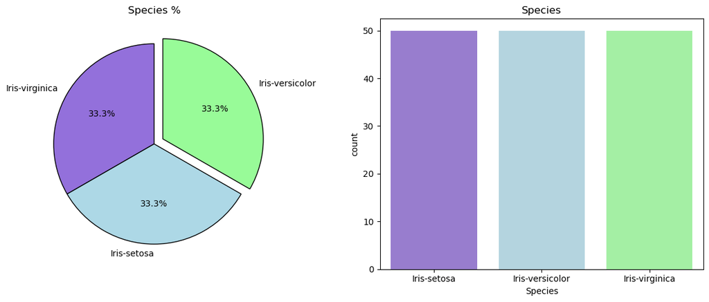

```python
import matplotlib.pyplot as plt
import seaborn as sns
import pandas as pd

# Sample iris DataFrame for demonstration
data = {
    'Species': ['Iris-setosa', 'Iris-versicolor', 'Iris-virginica'] * 50
}
iris = pd.DataFrame(data)

colors = ["#9370DB", "#ADD8E6", "#98FB98"] # Adjust colors as needed

# Calculate the percentage of each species
l = list(iris['Species'].value_counts())
circle = [l[1] / sum(l) * 100, l[2] / sum(l) * 100, l[0] / sum(l) * 100]

# Create subplots
fig, ax = plt.subplots(nrows=1, ncols=2, figsize=(12, 5))

# Pie chart
plt.subplot(1, 2, 1)
plt.pie(circle, labels=['Iris-virginica', 'Iris-setosa', 'Iris-versicolor'], autopct='%1.1f%%', startangle=90,
        explode=(0, 0, 0.1), colors=colors, wedgeprops={'edgecolor': 'black', 'linewidth': 1, 'antialiased': True})
plt.title('Species %')

# Count plot
plt.subplot(1, 2, 2)
sns.countplot(x='Species', data=iris, palette=colors)
plt.title('Species')

plt.tight_layout()
plt.show()
```

### 2.2 | Numerical Features Plotting

```python
continuous_values = continuous_values[1:]
```

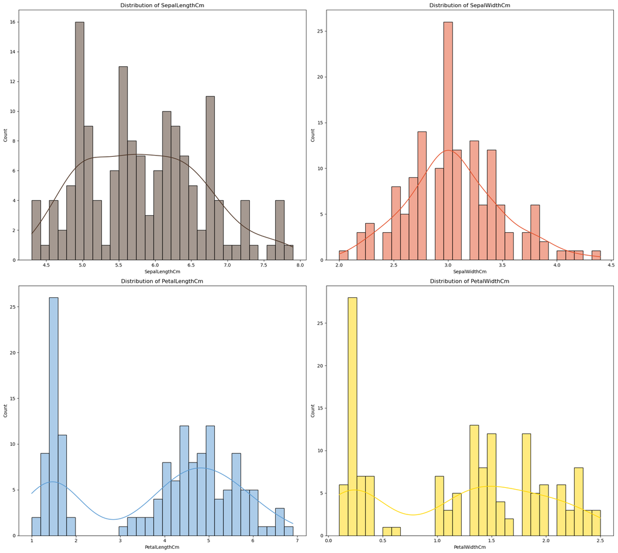

```python
# Create subplots with 5 rows and 2 columns
fig, ax = plt.subplots(nrows=2, ncols=2, figsize=(19, 17))

# Define colors for plots
colors = ['#4D3425', '#E4512B', '#5A9BD4', '#FFD700']

# Plot histograms for each column
for i, col in enumerate(continuous_values):
    plt.subplot(2, 2, i + 1)  # Adjust subplot index
    current_color = colors[i % len(colors)]
    sns.histplot(iris[col], kde=True, bins=30, color=current_color, edgecolor='black')
    plt.title(f'Distribution of {col}')
    plt.xlabel(col)

plt.tight_layout()
plt.show()
```

### 2.3 | Correlation of Numerical Features

```python
df_corr= iris[continuous_values].corr()
df_corr
```

|  | SepalLengthCm | SepalWidthCm | PetalLengthCm | PetalWidthCm |
| --- | --- | --- | --- | --- |
| SepalLengthCm | 1.000000 | -0.109369 | 0.871754 | 0.817954 |
| SepalWidthCm | -0.109369 | 1.000000 | -0.420516 | -0.356544 |
| PetalLengthCm | 0.871754 | -0.420516 | 1.000000 | 0.962757 |
| PetalWidthCm | 0.817954 | -0.356544 | 0.962757 | 1.000000 |

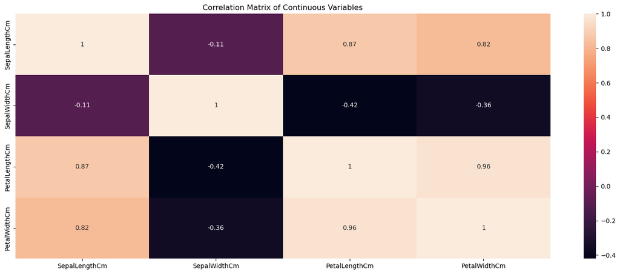

```python
plt.figure(figsize=(19,7))
sns.heatmap(df_corr, annot = True)
plt.title('Correlation Matrix of Continuous Variables')
plt.show()
```

### 2.4 | Distribution of Iris Species Within Each Feature

[figure not shown]

```python
# Create individual subplots for each species
fig, axes = plt.subplots(1, 3, figsize=(11, 5))

# Plot histograms for petal_length, petal_width, and sepal_length for each species
for i, species in enumerate(iris['species'].unique()):
    species_data = iris[iris['species'] == species]
    sns.histplot(species_data["petal_length"], kde=True, color="skyblue", bins=20, ax=axes[i], alpha=0.9)  # Increase opacity
    sns.histplot(species_data["petal_width"], kde=True, color="purple", bins=20, ax=axes[i], alpha=0.9)  # Increase opacity
    sns.histplot(species_data["sepal_length"], kde=True, color="green", bins=20, ax=axes[i], alpha=0.9)  # Increase opacity
    axes[i].set_title(species)
    axes[i].set_xlabel("Length")
    axes[i].set_ylabel("Frequency")
    axes[i].legend(["Petal Length", "Petal Width", "Sepal Length"])

# Adjust layout
plt.tight_layout()



# Show the plots
plt.show()
```

# 3. | Feature Engineering⚙️

### 3.1 | Outlier Detection & Removal

[output not shown]

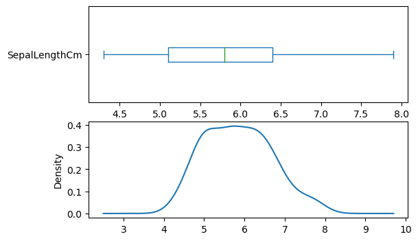

```
*********************** SepalWidthCm ***********************

lower outlier: 1 ****** upper outlier: 3
```

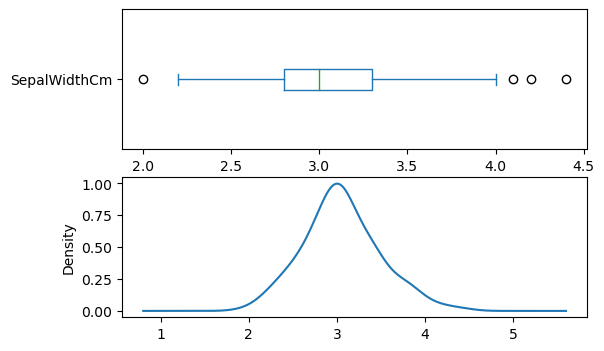

```
*********************** PetalLengthCm ***********************

lower outlier: 0 ****** upper outlier: 0
```

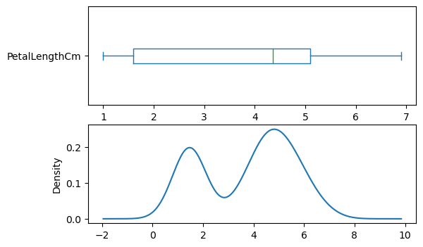

```
*********************** PetalWidthCm ***********************

lower outlier: 0 ****** upper outlier: 0
```

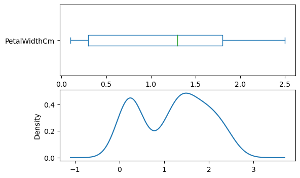

```python
def outlier_detect(df, col):
    q1_col = Q1[col]
    iqr_col = IQR[col]
    q3_col = Q3[col]
    return df[((df[col] < (q1_col - 1.5 * iqr_col)) |(df[col] > (q3_col + 1.5 * iqr_col)))]

# ---------------------------------------------------------
def outlier_detect_normal(df, col):
    m = df[col].mean()
    s = df[col].std()
    return df[((df[col]-m)/s).abs()>3]

# ---------------------------------------------------------
def lower_outlier(df, col):
    q1_col = Q1[col]
    iqr_col = IQR[col]
    q3_col = Q3[col]
    lower = df[(df[col] < (q1_col - 1.5 * iqr_col))]
    return lower

# ---------------------------------------------------------
def upper_outlier(df, col):
    q1_col = Q1[col]
    iqr_col = IQR[col]
    q3_col = Q3[col]
    upper = df[(df[col] > (q3_col + 1.5 * iqr_col))]
    return upper

# ---------------------------------------------------------
def replace_upper(df, outlier):
    for col in df.columns:
        if np.issubdtype(df[col].dtype, np.number):
            upper = df[col].quantile(0.75) + 1.5 * (df[col].quantile(0.75) - df[col].quantile(0.25))
            tmp = df[col].copy()
            df.loc[tmp > upper, col] = upper

def replace_lower(df, outlier):
    for col in df.columns:
        if np.issubdtype(df[col].dtype, np.number):
            lower = df[col].quantile(0.25) - 1.5 * (df[col].quantile(0.75) - df[col].quantile(0.25))
            tmp = df[col].copy()
            df.loc[tmp < lower, col] = lower

# ---------------------------------------------------------
# Writing Formulas For Upper & Lower Quartiles
Q1 = iris.quantile(0.25, numeric_only=True)
Q3 = iris.quantile(0.75, numeric_only=True)
IQR = Q3 - Q1

for i in range(len(continuous_values)):
    print("IQR => {}: {}".format(continuous_values[i], outlier_detect(iris, continuous_values[i]).shape[0]))
    print("Z_Score => {}: {}".format(continuous_values[i], outlier_detect_normal(iris, continuous_values[i]).shape[0]))
    print("********************************")


for i in range(len(continuous_values)):
    print("*********************** {} ***********************\n".format(continuous_values[i]))
    print("lower outlier: {} ****** upper outlier: {}\n".format(lower_outlier(iris, continuous_values[i]).shape[0], upper_outlier(iris, continuous_values[i]).shape[0]))
    plt.figure(figsize=(6, 4))  # Adjust the figsize here to reduce the graph size
    plt.subplot(2,1,1)
    iris[continuous_values[i]].plot(kind='box', subplots=True, sharex=False, vert=False)
    plt.subplot(2,1,2)
    iris[continuous_values[i]].plot(kind='density', subplots=True, sharex=False)
    plt.show()
```

```python
outlier = []
for i in range(len(continuous_values)):
    if outlier_detect(iris[continuous_values],continuous_values[i]).shape[0] !=0:
        outlier.append(continuous_values[i])

print("Numerical Variables With Outlier Values : ")
outlier
```

```
Numerical Variables With Outlier Values :
```

```
['SepalWidthCm']
```

```python
for i in range(len(outlier)):
    replace_upper(iris, outlier[i])

print("\n********************************\n")
for i in range(len(outlier)):
    replace_lower(iris, outlier[i])
```

```python
outlier = []
for i in range(len(continuous_values)):
    if outlier_detect(iris[continuous_values],continuous_values[i]).shape[0] !=0:
        outlier.append(continuous_values[i])

print("Numerical Variables With Outlier Values : ")
outlier
```

```
Numerical Variables With Outlier Values :
```

```
[]
```

### 3.2 | Label Encoding

```python
# Create a LabelEncoder object
le = LabelEncoder()
df1 = iris.copy(deep=True)
df1['Species'] = le.fit_transform(df1['Species'])

df1.tail(7)
```

|  | Id | SepalLengthCm | SepalWidthCm | PetalLengthCm | PetalWidthCm | Species |
| --- | --- | --- | --- | --- | --- | --- |
| 143 | 144.0 | 6.8 | 3.2 | 5.9 | 2.3 | 2 |
| 144 | 145.0 | 6.7 | 3.3 | 5.7 | 2.5 | 2 |
| 145 | 146.0 | 6.7 | 3.0 | 5.2 | 2.3 | 2 |
| 146 | 147.0 | 6.3 | 2.5 | 5.0 | 1.9 | 2 |
| 147 | 148.0 | 6.5 | 3.0 | 5.2 | 2.0 | 2 |
| 148 | 149.0 | 6.2 | 3.4 | 5.4 | 2.3 | 2 |
| 149 | 150.0 | 5.9 | 3.0 | 5.1 | 1.8 | 2 |

### 3.3 | Normalization

```python
# Create scaler objects
mms = MinMaxScaler()  # For Min-Max scaling (Normalization)
df2 = df1.copy(deep=True)

# Apply scaling using a loop
for col in continuous_values:
    df2[col] = mms.fit_transform(df2[[col]])

df2.head()
```

|  | Id | SepalLengthCm | SepalWidthCm | PetalLengthCm | PetalWidthCm | Species |
| --- | --- | --- | --- | --- | --- | --- |
| 0 | 1.0 | 0.222222 | 0.725 | 0.067797 | 0.041667 | 0 |
| 1 | 2.0 | 0.166667 | 0.475 | 0.067797 | 0.041667 | 0 |
| 2 | 3.0 | 0.111111 | 0.575 | 0.050847 | 0.041667 | 0 |
| 3 | 4.0 | 0.083333 | 0.525 | 0.084746 | 0.041667 | 0 |
| 4 | 5.0 | 0.194444 | 0.775 | 0.067797 | 0.041667 | 0 |

# 4. | Data Separation 🪓

```python
# Extract the selected features from the DataFrame
features = df2.drop(columns=['Species', 'Id'], axis=1).values
target = df2['Species'].values

# Split the data into training and testing sets
x_train, x_test, y_train, y_test = train_test_split(features, target, test_size=0.20, random_state=42)

print("Training set features shape:", x_train.shape)
print("Testing set features shape:", x_test.shape)
print("Training set target shape:", y_train.shape)
print("Testing set target shape:", y_test.shape)
```

```
Training set features shape: (120, 4)
Testing set features shape: (30, 4)
Training set target shape: (120,)
Testing set target shape: (30,)
```

### 4.1 | Saving Testing Features & Target

```python
import os
# Save the testing features
x_test_path = r'D:\Projects\Python\CodeSoft Internship\Iris_Project\x_test.csv'
if os.path.exists(x_test_path):
    os.remove(x_test_path)
x_test_df = pd.DataFrame(data=x_test)
x_test_df.to_csv(x_test_path, index=False)
print("Testing features saved successfully!")

# Save the testing target
y_test_path = r'D:\Projects\Python\CodeSoft Internship\Iris_Project\y_test.csv'
if os.path.exists(y_test_path):
    os.remove(y_test_path)
y_test_df = pd.DataFrame(data=y_test, columns=['species'])
y_test_df.to_csv(y_test_path, index=False)
print("Testing target saved successfully!")
```

```
Testing features saved successfully!
Testing target saved successfully!
```

# 5. | Model Training 🛠️

### 5.1 | Functions For Training & Evaluation

```python
def plot_confusion_matrix(cm, class_names):
    plt.figure(figsize=(8, 6))
    sns.heatmap(cm, annot=True, fmt='d', cmap='Blues', cbar=False,
                xticklabels=class_names, yticklabels=class_names)
    plt.title('Confusion Matrix')
    plt.xlabel('Predicted Labels')
    plt.ylabel('True Labels')
    plt.show()

def evaluate_classifier(classifier, x_test, y_test):
    # Confusion Matrix
    y_pred = classifier.predict(x_test)
    cm = confusion_matrix(y_test, y_pred)
    class_names = np.unique(y_test)
    plot_confusion_matrix(cm, class_names)

    # Classification Report
    print("\nClassification Report:\n", classification_report(y_test, y_pred))

    # ROC Curve (not applicable for multi-class classification)

def evaluate_model(classifier, x_train, y_train, x_test, y_test):
    classifier.fit(x_train, y_train)
    prediction = classifier.predict(x_test)

    # Calculate metrics
    accuracy = accuracy_score(y_test, prediction)
    precision = precision_score(y_test, prediction, average='weighted')
    recall = recall_score(y_test, prediction, average='weighted')
    f1 = f1_score(y_test, prediction, average='weighted')

    print("Training Accuracy: {:.2%}".format(classifier.score(x_train, y_train)))
    print("Test Accuracy: {:.2%}".format(accuracy))
    print("Precision: {:.2%}".format(precision))
    print("Recall: {:.2%}".format(recall))
    print("F1 Score: {:.2%}".format(f1))


    # Evaluation
    evaluate_classifier(classifier, x_test, y_test)
```

```python
from sklearn.linear_model import LogisticRegression
from sklearn.svm import SVC
from sklearn.ensemble import HistGradientBoostingClassifier

rf = RandomForestClassifier()
mlp = MLPClassifier(max_iter=1000)
lr = LogisticRegression()
knn = KNeighborsClassifier()
svm = SVC()
naive_bayes = GaussianNB()
```

# 6. | Model Evaluation 📊

### 6.1 | Naive Bayes

```python
model0 = evaluate_model(naive_bayes, x_train, y_train, x_test, y_test)
```

[output not shown]

```
Training Accuracy: 95.00%
Test Accuracy: 100.00%
Precision: 100.00%
Recall: 100.00%
F1 Score: 100.00%
```

```
Classification Report:
               precision    recall  f1-score   support

           0       1.00      1.00      1.00        10
           1       1.00      1.00      1.00         9
           2       1.00      1.00      1.00        11

    accuracy                           1.00        30
   macro avg       1.00      1.00      1.00        30
weighted avg       1.00      1.00      1.00        30
```

### 6.2 | KNN

```python
model1 = evaluate_model(knn, x_train, y_train, x_test, y_test)
```

[output not shown]

[output not shown]

```
Classification Report:
               precision    recall  f1-score   support

           0       1.00      1.00      1.00        10
           1       1.00      1.00      1.00         9
           2       1.00      1.00      1.00        11

    accuracy                           1.00        30
   macro avg       1.00      1.00      1.00        30
weighted avg       1.00      1.00      1.00        30
```

### 6.3 | Logistic Regression

```
Training Accuracy: 92.50%
Test Accuracy: 96.67%
Precision: 96.94%
Recall: 96.67%
F1 Score: 96.64%
```

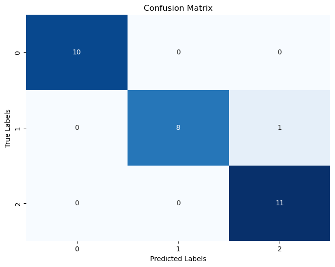

```
Classification Report:
               precision    recall  f1-score   support

           0       1.00      1.00      1.00        10
           1       1.00      0.89      0.94         9
           2       0.92      1.00      0.96        11

    accuracy                           0.97        30
   macro avg       0.97      0.96      0.97        30
weighted avg       0.97      0.97      0.97        30
```

```python
model2 = evaluate_model(lr, x_train, y_train, x_test, y_test)
```

### 6.4 | SVC

```python
model5 = evaluate_model(svm, x_train, y_train, x_test, y_test)
```

[output not shown]

```
Training Accuracy: 97.50%
Test Accuracy: 100.00%
Precision: 100.00%
Recall: 100.00%
F1 Score: 100.00%
```

```
Classification Report:
               precision    recall  f1-score   support

           0       1.00      1.00      1.00        10
           1       1.00      1.00      1.00         9
           2       1.00      1.00      1.00        11

    accuracy                           1.00        30
   macro avg       1.00      1.00      1.00        30
weighted avg       1.00      1.00      1.00        30
```

### 6.5 | MLP Classifier

```
Training Accuracy: 97.50%
Test Accuracy: 96.67%
Precision: 96.94%
Recall: 96.67%
F1 Score: 96.64%
```

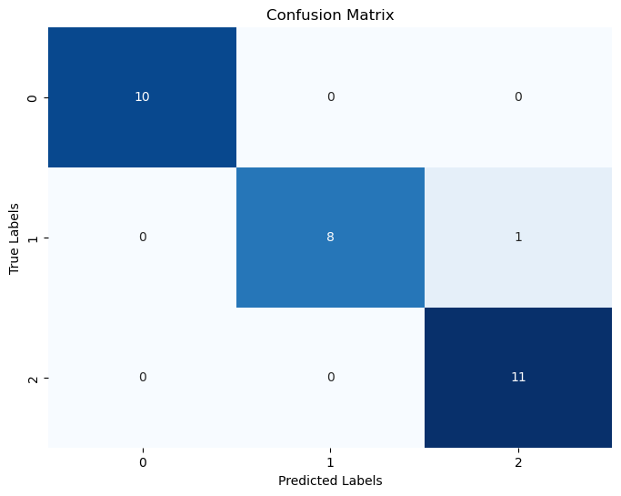

```
Classification Report:
               precision    recall  f1-score   support

           0       1.00      1.00      1.00        10
           1       1.00      0.89      0.94         9
           2       0.92      1.00      0.96        11

    accuracy                           0.97        30
   macro avg       0.97      0.96      0.97        30
weighted avg       0.97      0.97      0.97        30
```

```python
model4 = evaluate_model(mlp, x_train, y_train, x_test, y_test)
```

### 6.6 | Random Forest classifier

```python
model = evaluate_model(rf, x_train, y_train, x_test, y_test)
```

[output not shown]

```
Training Accuracy: 100.00%
Test Accuracy: 100.00%
Precision: 100.00%
Recall: 100.00%
F1 Score: 100.00%
```

```
Classification Report:
               precision    recall  f1-score   support

           0       1.00      1.00      1.00        10
           1       1.00      1.00      1.00         9
           2       1.00      1.00      1.00        11

    accuracy                           1.00        30
   macro avg       1.00      1.00      1.00        30
weighted avg       1.00      1.00      1.00        30
```

### 6.7 | Mean Accuracy for Each Model

```python
models = [rf, mlp, lr, knn, svm, naive_bayes]

# Compute mean accuracy for each model using cross-validation
mean_accuracies = []
for model in models:
    mean_accuracy = cross_val_score(model, x_train, y_train, cv=10, scoring='accuracy').mean()
    mean_accuracies.append(mean_accuracy)

# Calculate overall mean accuracy
overall_mean_accuracy = sum(mean_accuracies) / len(mean_accuracies)

# Report results
print("\nMean Accuracy for Each Model:")
for i, model in enumerate(models):
    print(f"{model.__class__.__name__}: {mean_accuracies[i]}")
print(f"\n\nOverall Mean Accuracy: {overall_mean_accuracy}")
```

```
Mean Accuracy for Each Model:
RandomForestClassifier: 0.9249999999999998
MLPClassifier: 0.9583333333333334
LogisticRegression: 0.9083333333333332
KNeighborsClassifier: 0.9333333333333332
SVC: 0.9333333333333332
GaussianNB: 0.9416666666666667


Overall Mean Accuracy: 0.9333333333333332
```

### 6.8 |CV Scores of Models

```python
# Compute cross-validation score for each model
cv_scores = {}
for model in models:
    scores = cross_val_score(model, x_train, y_train, cv=5, scoring='accuracy')
    cv_scores[model.__class__.__name__] = scores
    mean_score = scores.mean()

# Report cross-validation scores
for model_name, scores in cv_scores.items():
    print("-" * 50)
    print(f"{model_name}: \nCross-Validation Scores: {scores}")
    print(f"{model_name}: \nMean Score: {mean_score}")
```

```
--------------------------------------------------
RandomForestClassifier:
Cross-Validation Scores: [0.95833333 1.         0.875      1.         0.95833333]
RandomForestClassifier:
Mean Score: 0.9416666666666668
--------------------------------------------------
MLPClassifier:
Cross-Validation Scores: [0.95833333 1.         0.83333333 1.         1.        ]
MLPClassifier:
Mean Score: 0.9416666666666668
--------------------------------------------------
LogisticRegression:
Cross-Validation Scores: [0.83333333 1.         0.83333333 0.95833333 0.91666667]
LogisticRegression:
Mean Score: 0.9416666666666668
--------------------------------------------------
KNeighborsClassifier:
Cross-Validation Scores: [0.95833333 1.         0.79166667 1.         0.95833333]
KNeighborsClassifier:
Mean Score: 0.9416666666666668
--------------------------------------------------
SVC:
Cross-Validation Scores: [0.95833333 1.         0.83333333 1.         0.95833333]
SVC:
Mean Score: 0.9416666666666668
--------------------------------------------------
GaussianNB:
Cross-Validation Scores: [0.95833333 1.         0.83333333 1.         0.91666667]
GaussianNB:
Mean Score: 0.9416666666666668
```

# 7. | Models Comparison 📈

### 7.1 | Metrics Comparison

```python
rf = RandomForestClassifier()
rf.fit(x_train, y_train)
mlp = MLPClassifier(max_iter=1000)
mlp.fit(x_train, y_train)
lr = LogisticRegression()
lr.fit(x_train, y_train)
knn = KNeighborsClassifier()
knn.fit(x_train, y_train)
svm = SVC()
svm.fit(x_train, y_train)
naive_bayes = GaussianNB()
naive_bayes.fit(x_train, y_train)

models = [rf, mlp, lr, knn, svm, naive_bayes]


models = [rf, mlp, lr, knn, svm, naive_bayes]
# Define evaluation metrics
metrics = {
    'Test Accuracy': [],
    'Train Accuracy': [],
    'Precision': [],
    'Recall': [],
    'F1 Score': [],
    'Cross-Validation Mean Score': [],
    'Cross-Validation Scores': []
}

# Calculate metrics for each model
for model in models:
    # Test accuracy
    test_accuracy = accuracy_score(y_test, model.predict(x_test))
    metrics['Test Accuracy'].append(test_accuracy)

    # Train accuracy
    train_accuracy = accuracy_score(y_train, model.predict(x_train))
    metrics['Train Accuracy'].append(train_accuracy)

    # Precision
    precision = precision_score(y_test, model.predict(x_test), average='weighted')
    metrics['Precision'].append(precision)

    # Recall
    recall = recall_score(y_test, model.predict(x_test), average='weighted')
    metrics['Recall'].append(recall)

    # F1 score
    f1 = f1_score(y_test, model.predict(x_test), average='weighted')
    metrics['F1 Score'].append(f1)

    # Cross-validation scores
    cv_scores = cross_val_score(model, x_train, y_train, cv=5, scoring='accuracy')
    metrics['Cross-Validation Scores'].append(cv_scores.tolist())

    # Cross-validation mean score
    cv_mean_score = np.mean(cv_scores)
    metrics['Cross-Validation Mean Score'].append(cv_mean_score)

# Create a DataFrame from the metrics
metrics_df = pd.DataFrame(metrics, index=[model.__class__.__name__ for model in models])

# Display the DataFrame
print("\nMetrics for Each Model:")
metrics_df
```

```
Metrics for Each Model:
```

|  | Test Accuracy | Train Accuracy | Precision | Recall | F1 Score | Cross-Validation Mean Score | Cross-Validation Scores |
| --- | --- | --- | --- | --- | --- | --- | --- |
| RandomForestClassifier | 1.000000 | 1.000000 | 1.000000 | 1.000000 | 1.000000 | 0.958333 | [0.9583333333333334, 1.0, 0.875, 1.0, 0.958333... |
| MLPClassifier | 0.966667 | 0.975000 | 0.969444 | 0.966667 | 0.966411 | 0.958333 | [0.9583333333333334, 1.0, 0.8333333333333334, ... |
| LogisticRegression | 0.966667 | 0.925000 | 0.969444 | 0.966667 | 0.966411 | 0.908333 | [0.8333333333333334, 1.0, 0.8333333333333334, ... |
| KNeighborsClassifier | 1.000000 | 0.958333 | 1.000000 | 1.000000 | 1.000000 | 0.958333 | [0.9583333333333334, 1.0, 0.875, 1.0, 0.958333... |
| SVC | 1.000000 | 0.975000 | 1.000000 | 1.000000 | 1.000000 | 0.958333 | [0.9583333333333334, 1.0, 0.875, 1.0, 0.958333... |
| GaussianNB | 1.000000 | 0.950000 | 1.000000 | 1.000000 | 1.000000 | 0.941667 | [0.9583333333333334, 1.0, 0.8333333333333334, ... |

### 7.2 | Metrics Heatmap

[figure not shown]

```python
# Calculate summary statistics for cross-validation scores
cv_mean_scores = metrics_df['Cross-Validation Scores'].apply(np.mean)
cv_std_scores = metrics_df['Cross-Validation Scores'].apply(np.std)

# Create a new DataFrame with summary statistics
cv_summary_df = pd.DataFrame({'Cross-Validation Mean Score': cv_mean_scores, 'Cross-Validation Std Score': cv_std_scores})

# Combine the summary statistics with other metrics
combined_metrics_df = pd.concat([metrics_df.drop(columns=['Cross-Validation Scores']), cv_summary_df], axis=1)

# Plot a heatmap
plt.figure(figsize=(12, 8))
sns.heatmap(combined_metrics_df, annot=True, cmap='coolwarm', fmt='.4f', cbar=True)
plt.title('Comparison of Models')
plt.xlabel('Metrics')
plt.ylabel('Models')
plt.xticks()
plt.tight_layout()
plt.show()
```

### 7.3 | Finding Best Model

```python
# Define models with best hyperparameters
models = {
    'Random Forest': rf,
    'MLP': mlp,
    'Logistic Regression': lr,
    'KNN': knn,
    'SVM': svm,
    'Naive Bayes': GaussianNB()
}

# Initialize a list to store results
results = []

# Function to evaluate models
def evaluate_model(model, x_train, y_train, x_test, y_test):
    model.fit(x_train, y_train)
    y_pred_train = model.predict(x_train)
    y_pred_test = model.predict(x_test)

    train_accuracy = accuracy_score(y_train, y_pred_train)
    test_accuracy = accuracy_score(y_test, y_pred_test)

    cv = RepeatedStratifiedKFold(n_splits=10, n_repeats=3, random_state=1)
    cv_scores = cross_val_score(model, x_train, y_train, cv=cv, scoring='accuracy')

    return {
        'Train Accuracy': train_accuracy,
        'Test Accuracy': test_accuracy,
        'CV Mean Score': np.mean(cv_scores),
        'CV Std Dev': np.std(cv_scores)
    }

# Evaluate each model and store results
for model_name, model in models.items():
    metrics = evaluate_model(model, x_train, y_train, x_test, y_test)
    metrics['Model'] = model_name
    results.append(metrics)

# Create a DataFrame from the results
metrics_df = pd.DataFrame(results)

# Display results
print(metrics_df)

# Determine the best model based on the highest test accuracy
best_model_name = metrics_df.loc[metrics_df['Test Accuracy'].idxmax()]['Model']
print(f"\nBest Model: {best_model_name}\n")
```

```
   Train Accuracy  Test Accuracy  CV Mean Score  CV Std Dev  \
0        1.000000       1.000000       0.930556    0.068324
1        0.975000       0.966667       0.958333    0.063647
2        0.925000       0.966667       0.916667    0.074536
3        0.958333       1.000000       0.950000    0.055277
4        0.975000       1.000000       0.955556    0.055833
5        0.950000       1.000000       0.941667    0.065085

                 Model
0        Random Forest
1                  MLP
2  Logistic Regression
3                  KNN
4                  SVM
5          Naive Bayes

Best Model: Random Forest
```

## Model Comparison Insights 🎯

[output not shown]

# 8. | Predictions (2-Ways) 📉

### 8.1 | Manual Way

```python
# Define a dictionary to store results for all models
results = {}

# Make predictions for each model
for model_name, model in zip(['RandomForest', 'MLP', 'LogisticRegression', 'KNN', 'SVM', 'Naive_Bayes'], [rf, mlp, lr, knn, svm, naive_bayes]):
    # Make predictions on the test set
    y_pred = model.predict(x_test)

    # Create a DataFrame with selected features and predictions
    result_df = pd.DataFrame({'Actual': y_test, 'Predicted': y_pred})

    # Reset index to remove default index
    result_df.reset_index(drop=True, inplace=True)

    # Store the result DataFrame in the results dictionary
    results[model_name] = result_df

# Display only 7 values for each model
for model_name, result_df in results.items():
    print(f"Results for {model_name}:\n")
    print(result_df.head(7).to_string(index=False))  # Use head(7) to display only 7 rows
    print('*' * 80, "\n")
```

```
Results for RandomForest:

 Actual  Predicted
      1          1
      0          0
      2          2
      1          1
      1          1
      0          0
      1          1

Results for MLP:

 Actual  Predicted
      1          1
      0          0
      2          2
      1          1
      1          1
      0          0
      1          1

Results for LogisticRegression:

 Actual  Predicted
      1          1
      0          0
      2          2
      1          1
      1          1
      0          0
      1          1

Results for KNN:

 Actual  Predicted
      1          1
      0          0
      2          2
      1          1
```

[output cut: 10 more lines]

```
      1          1
      1          1
      0          0
      1          1

Results for Naive_Bayes:

 Actual  Predicted
      1          1
      0          0
      2          2
      1          1
      1          1
      0          0
      1          1
```

### **8.2 | User-Defined Way**

```python
def predict_iris_species(model, input_data):
    # Make prediction using the model
    prediction = model.predict([input_data])
    # Convert the predicted species index to actual species name
    species_mapping = {0: 'Iris-setosa', 1: 'Iris-versicolor', 2: 'Iris-virginica'}
    predicted_species = species_mapping[prediction[0]]
    # Return the predicted species
    return predicted_species

model = svm  # Assuming you have a trained Random Forest model

# Function to take input from the user
def get_user_input():
    sepal_length = float(input("Enter Sepal Length: "))
    sepal_width = float(input("Enter Sepal Width: "))
    petal_length = float(input("Enter Petal Length: "))
    petal_width = float(input("Enter Petal Width: "))

    # Convert input data to a list
    input_data_as_list = [sepal_length, sepal_width, petal_length, petal_width]

    return input_data_as_list

# Get input data from the user
input_data = get_user_input()

# Predict the species
predicted_species = predict_iris_species(model, input_data)

# Print the predicted species
print("Predicted Iris Species:", predicted_species)


#0.5	0.375	0.508474576	0.5
```

```
Enter Sepal Length: 0.5
Enter Sepal Width: 0.38
Enter Petal Length: 0.5
Enter Petal Width: 0.5
Predicted Iris Species: Iris-versicolor
```

# 10. | Saving Models 🧪

```python
import joblib
joblib_file = "RandomForest_model.pkl"
joblib.dump(rf, joblib_file)
print(f"Model saved as {joblib_file}")

# Load the model using joblib
loaded_model = joblib.load(joblib_file)
print("Model loaded.")

# Evaluate the loaded model
result = loaded_model.score(x_test, y_test)
print(f"Model accuracy: {result}")
```

```
Model saved as RandomForest_model.pkl
Model loaded.
Model accuracy: 1.0
```

### 10.2 | 2nd Best Model

```python
import joblib
joblib_file = "SVM_model.pkl"
joblib.dump(svm, joblib_file)
print(f"Model saved as {joblib_file}")

# Load the model using joblib
svm_model = joblib.load(joblib_file)
print("Model loaded.")

# Evaluate the loaded model
result = svm_model.score(x_test, y_test)
print(f"Model accuracy: {result}")
```

```
Model saved as SVM_model.pkl
Model loaded.
Model accuracy: 1.0
```